# E2. Preparación y Modelado de los datos

12 de Mayo del 2022

- Equipo 3
  - Ximena Martínez A00829670
  - Chantal Aimeé Simó A00827554
  - Carolina Velarde A01720509
  - Kízari Hernández A00828451

## Fraud Detection System - Modelado de las bases de datos (Clasificación)

### **Demographic Dataset**

**Preprocesamiento de los datos**

Para que los modelos puedan correr adecuadamente, necesitamos eliminar varibales con muchos niveles y también variables innecesarias.

```r
# Importar los datos
DData <- read_excel("DData.xlsx")
DData  %<>% select( -"...1", -First,-Last,-Street,-City, -State, -Job, -Merchant)
```

```r
# Convertir a factor lo que esté como character
#str(DData)
DData[sapply(DData, is.character)] <- lapply(DData[sapply(DData, is.character)], as.factor)
DData$Is_Fraud <- as.factor(DData$Is_Fraud)
```

**Splitting Train/Test:**

Antes de comenzar con los modelos, necesitamos hacer el split de la base de datos en train y test

```r
set.seed(123)
split = sample.split(DData$Is_Fraud, SplitRatio = 0.70)
train_set = subset(DData, split == TRUE)
test_set = subset(DData, split == FALSE)
rm(split)
#colnames(train_set)
```

### Modelos de clasificación

Ya con nuestros datos divididos comenzamos a realizar el modelado. Dentro de nuestra investigación encontramos cuales son los principales modelos que se utilizan para la detección de fraude. De estos realizamos 8 modelos.

#### M1. Regresión Logística

**Creación del modelo**

```r
classifier = glm(formula = Is_Fraud ~ Category + Amount + Gender + Zip + Lat + Long + City_Population + Schedule,
                 family = binomial,
                 data = train_set) #%>% MASS::stepAIC(trace = T)
summary(classifier)
```

```
##
## Call:
## glm(formula = Is_Fraud ~ Category + Amount + Gender + Zip + Lat +
##     Long + City_Population + Schedule, family = binomial, data = train_set)
##
## Deviance Residuals:
##     Min       1Q   Median       3Q      Max
## -8.4904  -0.5106  -0.0382   0.4088   2.5532
##
## Coefficients:
##                          Estimate Std. Error z value Pr(>|z|)
## (Intercept)            -2.777e+00  4.203e-01  -6.607 3.93e-11 ***
## Categoryfood_dining     1.165e+00  1.965e-01   5.928 3.08e-09 ***
## Categorygas_transport   3.341e+00  2.047e-01  16.323  < 2e-16 ***
## Categorygrocery_net     3.175e+00  2.338e-01  13.581  < 2e-16 ***
## Categorygrocery_pos     2.505e+00  1.905e-01  13.146  < 2e-16 ***
## Categoryhealth_fitness  1.339e+00  2.004e-01   6.678 2.42e-11 ***
## Categoryhome            4.041e-01  1.925e-01   2.099   0.0358 *
## Categorykids_pets       1.408e+00  1.878e-01   7.501 6.33e-14 ***
## Categorymisc_net       -1.760e-01  2.657e-01  -0.662   0.5077
## Categorymisc_pos        2.161e+00  1.988e-01  10.872  < 2e-16 ***
## Categorypersonal_care   1.714e+00  1.916e-01   8.947  < 2e-16 ***
## Categoryshopping_net   -1.829e+00  2.730e-01  -6.701 2.07e-11 ***
## Categoryshopping_pos   -1.122e+00  2.506e-01  -4.475 7.63e-06 ***
## Categorytravel          1.722e+00  2.239e-01   7.690 1.48e-14 ***
## Amount                  9.132e-03  2.604e-04  35.069  < 2e-16 ***
## GenderM                -2.585e-01  6.101e-02  -4.237 2.27e-05 ***
## Zip                     1.835e-06  2.895e-06   0.634   0.5262
## Lat                    -2.926e-04  6.356e-03  -0.046   0.9633
## Long                    5.701e-03  5.622e-03   1.014   0.3105
## City_Population        -7.592e-08  9.023e-08  -0.841   0.4001
## ScheduleMañana         -2.125e+00  1.029e-01 -20.655  < 2e-16 ***
## ScheduleNoche           9.713e-01  1.304e-01   7.450 9.33e-14 ***
## ScheduleTarde          -1.127e+00  1.493e-01  -7.545 4.52e-14 ***
## ---
## Signif. codes:  0 '***' 0.001 '**' 0.01 '*' 0.05 '.' 0.1 ' ' 1
##
## (Dispersion parameter for binomial family taken to be 1)
##
##     Null deviance: 14555.7  on 10499  degrees of freedom
## Residual deviance:  6990.7  on 10477  degrees of freedom
## AIC: 7036.7
##
## Number of Fisher Scoring iterations: 7
```

**Analizando resultados**

- Accuracy: 0.8353
- Sensitivity: 0.9360
- Specificity: 0.7335

```r
prob_pred = predict(classifier, newdata = test_set)
y_pred = ifelse(prob_pred > 0.5, 1, 0)
y_pred <- as.factor(y_pred)
confusionMatrix(data = y_pred, reference = test_set$Is_Fraud)
```

```
## Confusion Matrix and Statistics
##
##           Reference
## Prediction    0    1
##          0 2119  596
##          1  145 1640
##
##                Accuracy : 0.8353
##                  95% CI : (0.8242, 0.8461)
##     No Information Rate : 0.5031
##     P-Value [Acc > NIR] : < 2.2e-16
##
##                   Kappa : 0.6702
##
##  Mcnemar's Test P-Value : < 2.2e-16
##
##             Sensitivity : 0.9360
##             Specificity : 0.7335
##          Pos Pred Value : 0.7805
##          Neg Pred Value : 0.9188
##              Prevalence : 0.5031
##          Detection Rate : 0.4709
##    Detection Prevalence : 0.6033
##       Balanced Accuracy : 0.8347
##
##        'Positive' Class : 0
##
```

**Prueba ROC/AUC**

- AUC: 0.8347

```r
y_pred <- as.numeric(y_pred)
rocRL <- roc(test_set$Is_Fraud, y_pred)
auc(test_set$Is_Fraud, y_pred)# Area AUC:
```

```
## Area under the curve: 0.8347
```

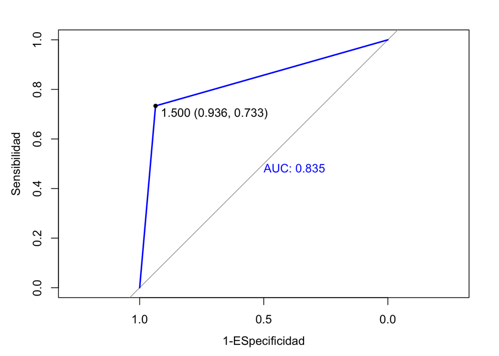

```r
plot.roc(rocRL,print.auc=T,print.thres = "best",
          col="blue",xlab="1-ESpecificidad",ylab="Sensibilidad")
```

**Multicollinearity & Autocorrelation**

```r
car::vif(classifier) # multicollinearity is NOT present with results greater than 10
```

```
##                      GVIF Df GVIF^(1/(2*Df))
## Category        13.815167 13        1.106267
## Amount           2.986462  1        1.728138
## Gender           1.045241  1        1.022370
## Zip              6.911373  1        2.628949
## Lat              1.194306  1        1.092843
## Long             6.880234  1        2.623020
## City_Population  1.058442  1        1.028806
## Schedule         4.713150  3        1.294847
```

```r
lmtest::dwtest(classifier) #DW = 0.01 autocorrelation is NOT present
```

```
##
##  Durbin-Watson test
##
## data:  classifier
## DW = 0.98691, p-value < 2.2e-16
## alternative hypothesis: true autocorrelation is greater than 0
```

#### M2. Support Vector Machine (SVM)

**Creación del modelo**

```r
set.seed(123)
classifierSVM = svm(formula = Is_Fraud ~ .,
                 data = train_set,
                 type = 'C-classification',
                 kernel = 'linear')

summary(classifierSVM)
```

```
##
## Call:
## svm(formula = Is_Fraud ~ ., data = train_set, type = "C-classification",
##     kernel = "linear")
##
##
## Parameters:
##    SVM-Type:  C-classification
##  SVM-Kernel:  linear
##        cost:  1
##
## Number of Support Vectors:  2946
##
##  ( 1475 1471 )
##
##
## Number of Classes:  2
##
## Levels:
##  0 1
```

```r
classifierSVM
```

```
##
## Call:
## svm(formula = Is_Fraud ~ ., data = train_set, type = "C-classification",
##     kernel = "linear")
##
##
## Parameters:
##    SVM-Type:  C-classification
##  SVM-Kernel:  linear
##        cost:  1
##
## Number of Support Vectors:  2946
```

**Analizando resultados**

- Accuracy: 0.8891
- Sensitivity: 0.8507
- Specificity: 0.9280

```r
y_predSVM = predict(classifierSVM, newdata = test_set[-8])
confusionMatrix(data = y_predSVM, reference = test_set$Is_Fraud)
```

```
## Confusion Matrix and Statistics
##
##           Reference
## Prediction    0    1
##          0 1926  161
##          1  338 2075
##
##                Accuracy : 0.8891
##                  95% CI : (0.8796, 0.8981)
##     No Information Rate : 0.5031
##     P-Value [Acc > NIR] : < 2.2e-16
##
##                   Kappa : 0.7783
##
##  Mcnemar's Test P-Value : 3.304e-15
##
##             Sensitivity : 0.8507
##             Specificity : 0.9280
##          Pos Pred Value : 0.9229
##          Neg Pred Value : 0.8599
##              Prevalence : 0.5031
##          Detection Rate : 0.4280
##    Detection Prevalence : 0.4638
##       Balanced Accuracy : 0.8894
##
##        'Positive' Class : 0
##
```

**Prueba ROC/AUC**

- AUC: 0.8894

```r
y_predSVM <- as.numeric(y_predSVM)
rocSVM <- roc(test_set$Is_Fraud, y_predSVM)
auc(test_set$Is_Fraud, y_predSVM)# Area AUC:
```

```
## Area under the curve: 0.8894
```

```r
plot.roc(rocSVM,print.auc=T,print.thres = "best",
          col="blue",xlab="1-ESpecificidad",ylab="Sensibilidad")
```

[output not shown]

#### M3. Kernel

**Creación del modelo**

```r
set.seed(123)
classifierKER = svm(formula = Is_Fraud ~ .,
                 data = train_set,
                 type = 'C-classification',
                 kernel = 'radial')

classifierKER
```

```
##
## Call:
## svm(formula = Is_Fraud ~ ., data = train_set, type = "C-classification",
##     kernel = "radial")
##
##
## Parameters:
##    SVM-Type:  C-classification
##  SVM-Kernel:  radial
##        cost:  1
##
## Number of Support Vectors:  3501
```

**Analizando resultados**

- Accuracy: 0.8851
- Sensitivity: 0.8405
- Specificity: 0.9302

```r
y_predKER = predict(classifierKER, newdata = test_set[-8])
confusionMatrix(data = y_predKER, reference = test_set$Is_Fraud)
```

```
## Confusion Matrix and Statistics
##
##           Reference
## Prediction    0    1
##          0 1903  156
##          1  361 2080
##
##                Accuracy : 0.8851
##                  95% CI : (0.8754, 0.8943)
##     No Information Rate : 0.5031
##     P-Value [Acc > NIR] : < 2.2e-16
##
##                   Kappa : 0.7703
##
##  Mcnemar's Test P-Value : < 2.2e-16
##
##             Sensitivity : 0.8405
##             Specificity : 0.9302
##          Pos Pred Value : 0.9242
##          Neg Pred Value : 0.8521
##              Prevalence : 0.5031
##          Detection Rate : 0.4229
##    Detection Prevalence : 0.4576
##       Balanced Accuracy : 0.8854
##
##        'Positive' Class : 0
##
```

**Prueba ROC/AUC**

- AUC: 0.8854

```r
y_predKER <- as.numeric(y_predKER)
rocKER <- roc(test_set$Is_Fraud, y_predKER)
auc(test_set$Is_Fraud, y_predKER)# Area AUC:
```

```
## Area under the curve: 0.8854
```

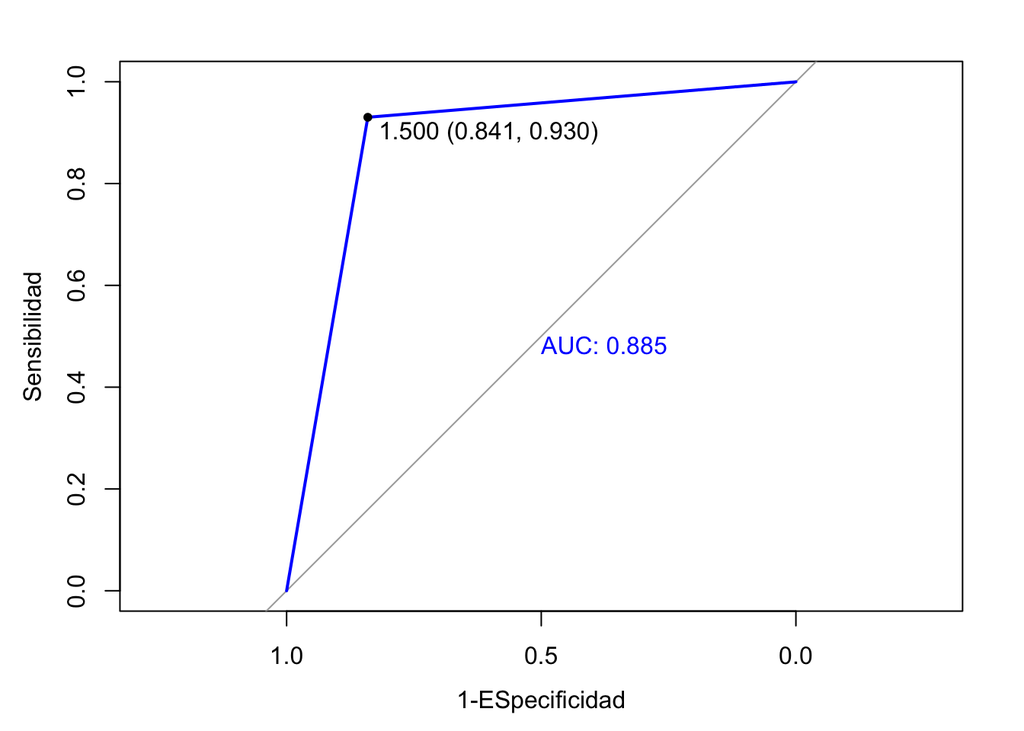

```r
plot.roc(rocKER,print.auc=T,print.thres = "best",
          col="blue",xlab="1-ESpecificidad",ylab="Sensibilidad")
```

#### M4. Naïve Bayes

**Creación del modelo**

```r
set.seed(123)
classifierNB = naiveBayes(x = train_set,
                        y = train_set$Is_Fraud)
```

**Analizando resultados**

- Accuracy: 0.8196
- Sensitivity: 0.8728
- Specificity: 0.7657

```r
y_predNB = predict(classifierNB, newdata = test_set[-8])
confusionMatrix(data = y_predNB, reference = test_set$Is_Fraud)
```

```
## Confusion Matrix and Statistics
##
##           Reference
## Prediction    0    1
##          0 1976  524
##          1  288 1712
##
##                Accuracy : 0.8196
##                  95% CI : (0.808, 0.8307)
##     No Information Rate : 0.5031
##     P-Value [Acc > NIR] : < 2.2e-16
##
##                   Kappa : 0.6389
##
##  Mcnemar's Test P-Value : < 2.2e-16
##
##             Sensitivity : 0.8728
##             Specificity : 0.7657
##          Pos Pred Value : 0.7904
##          Neg Pred Value : 0.8560
##              Prevalence : 0.5031
##          Detection Rate : 0.4391
##    Detection Prevalence : 0.5556
##       Balanced Accuracy : 0.8192
##
##        'Positive' Class : 0
##
```

**Prueba ROC/AUC**

- AUC: 0.8192

```r
y_predNB <- as.numeric(y_predNB)
rocNB <- roc(test_set$Is_Fraud, y_predNB)
auc(test_set$Is_Fraud, y_predNB)# Area AUC:
```

```
## Area under the curve: 0.8192
```

```r
plot.roc(rocNB,print.auc=T,print.thres = "best",
          col="blue",xlab="1-ESpecificidad",ylab="Sensibilidad")
```

[output not shown]

#### M5. Naïve Bayes Glm

**Creación del modelo**

```r
classifierNBglm <- arm::bayesglm(formula = Is_Fraud ~ .,
                                 family = "binomial",
                                 data = train_set) %>% MASS::stepAIC(trace = T)
```

```
## Start:  AIC=5942.84
## Is_Fraud ~ Category + Amount + Gender + Zip + Lat + Long + City_Population +
##     Hour + Schedule
```

```
##                   Df Deviance    AIC
## - Lat              4   5848.4 5932.4
## - Zip              4   5848.4 5932.4
## - Long             4   5849.0 5933.0
## - City_Population  4   5849.3 5933.3
## - Schedule         3   5848.3 5934.3
## - Gender           4   5855.7 5939.7
## <none>                 5850.8 5942.8
## - Category        16   6667.7 6727.7
## - Hour            23   6990.7 7036.7
## - Amount           4   8716.4 8800.4
```

```
##
## Step:  AIC=5940.96
## Is_Fraud ~ Category + Amount + Gender + Zip + Long + City_Population +
##     Hour + Schedule
```

```
##                   Df Deviance    AIC
## - Zip              4   5848.7 5930.7
## - City_Population  4   5849.3 5931.3
## - Long             4   5849.4 5931.4
## - Schedule         3   5848.4 5932.4
## - Gender           4   5855.9 5937.9
## <none>                 5851.0 5941.0
## - Category        16   6668.1 6726.1
## - Hour            23   6990.7 7034.7
## - Amount           4   8717.3 8799.3
```

```
##
## Step:  AIC=5939.32
## Is_Fraud ~ Category + Amount + Gender + Long + City_Population +
##     Hour + Schedule
```

```
##                   Df Deviance    AIC
## - City_Population  4   5849.5 5929.5
## - Long             4   5850.1 5930.1
## - Schedule         3   5848.7 5930.7
## - Gender           4   5856.3 5936.3
## <none>                 5851.3 5939.3
## - Category        16   6668.2 6724.2
## - Hour            23   6991.2 7033.2
## - Amount           4   8718.5 8798.5
```

```
##
## Step:  AIC=5938.1
## Is_Fraud ~ Category + Amount + Gender + Long + Hour + Schedule
```

```
##            Df Deviance    AIC
## - Long      4   5851.1 5929.1
## - Schedule  3   5849.5 5929.5
## - Gender    4   5857.0 5935.0
## <none>          5852.1 5938.1
## - Category 16   6669.8 6723.8
## - Hour     23   6991.8 7031.8
## - Amount    4   8718.6 8796.6
```

```
##
## Step:  AIC=5937.65
## Is_Fraud ~ Category + Amount + Gender + Hour + Schedule
```

```
##            Df Deviance    AIC
## - Schedule  3   5851.1 5929.1
## - Gender    4   5858.3 5934.3
## <none>          5853.6 5937.6
## - Category 16   6671.3 6723.3
## - Hour     23   6993.1 7031.1
## - Amount    4   8725.3 8801.3
```

```
##
## Step:  AIC=5932.29
## Is_Fraud ~ Category + Amount + Gender + Hour
```

```
##            Df Deviance    AIC
## <none>          5854.3 5932.3
## - Gender    1   5858.3 5934.3
## - Category 13   6671.3 6723.3
## - Hour     23   8061.8 8093.8
## - Amount    1   8725.3 8801.3
```

```r
jtools::summ(classifierNBglm)
```

| Observations | 10500 |
| --- | --- |
| Dependent variable | Is_Fraud |
| Type | Generalized linear model |
| Family | binomial |
| Link | logit |

| 𝛘²(38) | 8701.36 |
| --- | --- |
| Pseudo-R² (Cragg-Uhler) | 0.75 |
| Pseudo-R² (McFadden) | 0.60 |
| AIC | 5932.29 |
| BIC | 6215.39 |

|  | Est. | S.E. | z val. | p |
| --- | --- | --- | --- | --- |
| (Intercept) | -2.99 | 0.23 | -13.11 | 0.00 |
| Categoryfood_dining | 0.99 | 0.22 | 4.57 | 0.00 |
| Categorygas_transport | 3.17 | 0.22 | 14.62 | 0.00 |
| Categorygrocery_net | 3.07 | 0.25 | 12.44 | 0.00 |
| Categorygrocery_pos | 2.44 | 0.20 | 11.91 | 0.00 |
| Categoryhealth_fitness | 1.23 | 0.22 | 5.58 | 0.00 |
| Categoryhome | 0.13 | 0.22 | 0.57 | 0.57 |
| Categorykids_pets | 1.33 | 0.21 | 6.40 | 0.00 |
| Categorymisc_net | -0.14 | 0.28 | -0.50 | 0.62 |
| Categorymisc_pos | 1.95 | 0.22 | 9.05 | 0.00 |
| Categorypersonal_care | 1.62 | 0.21 | 7.62 | 0.00 |
| Categoryshopping_net | -1.62 | 0.29 | -5.61 | 0.00 |
| Categoryshopping_pos | -1.02 | 0.26 | -3.86 | 0.00 |
| Categorytravel | 1.38 | 0.24 | 5.68 | 0.00 |
| Amount | 0.01 | 0.00 | 32.96 | 0.00 |
| GenderM | -0.18 | 0.07 | -2.66 | 0.01 |
| Hour01 | 0.35 | 0.16 | 2.16 | 0.03 |
| Hour02 | 0.22 | 0.16 | 1.41 | 0.16 |
| Hour03 | 0.28 | 0.16 | 1.79 | 0.07 |
| Hour04 | -2.17 | 0.24 | -9.05 | 0.00 |
| Hour05 | -2.06 | 0.24 | -8.49 | 0.00 |
| Hour06 | -2.18 | 0.25 | -8.56 | 0.00 |
| Hour07 | -2.39 | 0.24 | -9.83 | 0.00 |
| Hour08 | -1.89 | 0.23 | -8.40 | 0.00 |
| Hour09 | -2.31 | 0.26 | -8.92 | 0.00 |
| Hour10 | -2.23 | 0.24 | -9.20 | 0.00 |
| Hour11 | -2.37 | 0.25 | -9.48 | 0.00 |
| Hour12 | -1.94 | 0.32 | -6.11 | 0.00 |
| Hour13 | -1.47 | 0.28 | -5.31 | 0.00 |
| Hour14 | -1.03 | 0.26 | -3.90 | 0.00 |
| Hour15 | -1.06 | 0.26 | -4.08 | 0.00 |
| Hour16 | -0.96 | 0.28 | -3.50 | 0.00 |
| Hour17 | -1.11 | 0.27 | -4.11 | 0.00 |
| Hour18 | -1.44 | 0.28 | -5.10 | 0.00 |
| Hour19 | -1.05 | 0.28 | -3.77 | 0.00 |
| Hour20 | -1.84 | 0.32 | -5.83 | 0.00 |
| Hour21 | -1.77 | 0.29 | -6.12 | 0.00 |
| Hour22 | 1.83 | 0.18 | 10.02 | 0.00 |
| Hour23 | 1.92 | 0.18 | 10.51 | 0.00 |

Standard errors: MLE

**Analizando resultados**

- Accuracy: 0.8776
- Sensitivity: 0.8905
- Specificity: 0.8645

```r
y_predNBglm = predict(classifierNBglm, newdata = test_set[-8])
y_predNBglm = as.factor(ifelse( y_predNBglm > 0.35, 1, 0))
confusionMatrix(data = y_predNBglm, reference = test_set$Is_Fraud)
```

```
## Confusion Matrix and Statistics
##
##           Reference
## Prediction    0    1
##          0 2016  303
##          1  248 1933
##
##                Accuracy : 0.8776
##                  95% CI : (0.8676, 0.887)
##     No Information Rate : 0.5031
##     P-Value [Acc > NIR] : < 2e-16
##
##                   Kappa : 0.7551
##
##  Mcnemar's Test P-Value : 0.02142
##
##             Sensitivity : 0.8905
##             Specificity : 0.8645
##          Pos Pred Value : 0.8693
##          Neg Pred Value : 0.8863
##              Prevalence : 0.5031
##          Detection Rate : 0.4480
##    Detection Prevalence : 0.5153
##       Balanced Accuracy : 0.8775
##
##        'Positive' Class : 0
##
```

**Prueba ROC/AUC**

- AUC: 0.8775

```r
y_predNBglm <- as.numeric(y_predNBglm)
rocNBglm <- roc(test_set$Is_Fraud, y_predNBglm)
auc(test_set$Is_Fraud, y_predNBglm)# Area AUC:
```

```
## Area under the curve: 0.8775
```

#### M6. Decision Tree

**Creación del modelo**

```r
set.seed(123)
classifierDT = rpart(formula = Is_Fraud ~ .,
                   data = train_set)
```

**Analizando resultados**

- Accuracy: 0.9422
- Sensitivity: 0.9452
- Specificity: 0.9392

```r
y_predDT = predict(classifierDT, newdata = test_set[-8], type = 'class')
confusionMatrix(data = y_predDT, reference = test_set$Is_Fraud)
```

```
## Confusion Matrix and Statistics
##
##           Reference
## Prediction    0    1
##          0 2140  136
##          1  124 2100
##
##                Accuracy : 0.9422
##                  95% CI : (0.935, 0.9489)
##     No Information Rate : 0.5031
##     P-Value [Acc > NIR] : <2e-16
##
##                   Kappa : 0.8844
##
##  Mcnemar's Test P-Value : 0.4951
##
##             Sensitivity : 0.9452
##             Specificity : 0.9392
##          Pos Pred Value : 0.9402
##          Neg Pred Value : 0.9442
##              Prevalence : 0.5031
##          Detection Rate : 0.4756
##    Detection Prevalence : 0.5058
##       Balanced Accuracy : 0.9422
##
##        'Positive' Class : 0
##
```

**Prueba ROC/AUC**

- AUC: 0.9422

```r
y_predDT <- as.numeric(y_predDT)
rocDT <- roc(test_set$Is_Fraud, y_predDT)
auc(test_set$Is_Fraud, y_predDT)# Area AUC:
```

```
## Area under the curve: 0.9422
```

```r
plot.roc(rocDT,print.auc=T,print.thres = "best",
          col="blue",xlab="1-ESpecificidad",ylab="Sensibilidad")
```

[output not shown]

#### M7. Random Forest

**Creación del modelo**

```r
classifierRF = randomForest(x = train_set[-8],
                          y = train_set$Is_Fraud,
                          ntree = 30, importance = T)

classifierRF$importance
```

```
##                            0           1 MeanDecreaseAccuracy MeanDecreaseGini
## Category        0.0355476586 0.280473208          0.156856832        656.00692
## Amount          0.2531384197 0.533303212          0.391801718       2938.93377
## Gender          0.0011319890 0.008803814          0.004930214         22.01434
## Zip             0.0125106837 0.016425682          0.014447133        102.03690
## Lat             0.0047199638 0.009113945          0.006906177         94.44841
## Long            0.0146411664 0.017053081          0.015841578         98.78977
## City_Population 0.0009568218 0.011317923          0.006084344        109.20184
## Hour            0.0596638811 0.060802389          0.060220722        931.56515
## Schedule        0.0327749167 0.027540990          0.030212231        288.71518
```

```r
plot(classifierRF)
```

[output not shown]

**Analizando resultados**

- Accuracy: 0.9773
- Sensitivity: 0.9726
- Specificity: 0.9821

```r
y_predRF = predict(classifierRF, newdata = test_set[-8])
confusionMatrix(data = y_predRF, reference = test_set$Is_Fraud)
```

```
## Confusion Matrix and Statistics
##
##           Reference
## Prediction    0    1
##          0 2202   40
##          1   62 2196
##
##                Accuracy : 0.9773
##                  95% CI : (0.9726, 0.9815)
##     No Information Rate : 0.5031
##     P-Value [Acc > NIR] : < 2e-16
##
##                   Kappa : 0.9547
##
##  Mcnemar's Test P-Value : 0.03759
##
##             Sensitivity : 0.9726
##             Specificity : 0.9821
##          Pos Pred Value : 0.9822
##          Neg Pred Value : 0.9725
##              Prevalence : 0.5031
##          Detection Rate : 0.4893
##    Detection Prevalence : 0.4982
##       Balanced Accuracy : 0.9774
##
##        'Positive' Class : 0
##
```

**Prueba ROC/AUC**

```r
y_predDT <- as.numeric(y_predDT)
rocRF <- roc(test_set$Is_Fraud, y_predDT)
auc(test_set$Is_Fraud, y_predDT)# Area AUC:
```

```
## Area under the curve: 0.9422
```

```r
plot.roc(rocRF,print.auc=T,print.thres = "best",
          col="blue",xlab="1-ESpecificidad",ylab="Sensibilidad")
```

[output not shown]

#### M8. Gradiente boosting classifier

**Creación del modelo**

```r
classifierGBC = gbm::gbm(Is_Fraud ~.,
                data = train_set,
                distribution = "multinomial",
                cv.folds = 10,
                shrinkage = .01,
                n.minobsinnode = 10,
                n.trees = 50)       # 60 tress to be built

summary(classifierGBC)
```

```
##                             var  rel.inf
## Amount                   Amount 75.83605
## Hour                       Hour 24.16395
## Category               Category  0.00000
## Gender                   Gender  0.00000
## Zip                         Zip  0.00000
## Lat                         Lat  0.00000
## Long                       Long  0.00000
## City_Population City_Population  0.00000
## Schedule               Schedule  0.00000
```

**Analizando resultados**

- Accuracy: 0.8704
- Sensitivity: 0.8071
- Specificity: 0.9688

```r
y_predGBC= gbm::predict.gbm(object = classifierGBC,
                   newdata = test_set[-8],
                   n.trees = 50,
                   type = "response")

class_names = colnames(y_predGBC)[apply(y_predGBC, 1, which.max)]
result = data.frame(test_set$Is_Fraud, class_names)
confusionMatrix(test_set$Is_Fraud, as.factor(class_names))
```

```
## Confusion Matrix and Statistics
##
##           Reference
## Prediction    0    1
##          0 2209   55
##          1  528 1708
##
##                Accuracy : 0.8704
##                  95% CI : (0.8603, 0.8801)
##     No Information Rate : 0.6082
##     P-Value [Acc > NIR] : < 2.2e-16
##
##                   Kappa : 0.7405
##
##  Mcnemar's Test P-Value : < 2.2e-16
##
##             Sensitivity : 0.8071
##             Specificity : 0.9688
##          Pos Pred Value : 0.9757
##          Neg Pred Value : 0.7639
##              Prevalence : 0.6082
##          Detection Rate : 0.4909
##    Detection Prevalence : 0.5031
##       Balanced Accuracy : 0.8879
##
##        'Positive' Class : 0
##
```

**————————————————————————————————-**

### **Device Dataset**

**Balanceo de datos**

Luego de la limpieza pasamos al balanceo de datos. Antes de comenzar este proceso, para esta base de datos eliminamos las variables tipo POSIXlt ya que estas no funcionaran en los modelos.

```r
# Previa regulación de datos
Devicedata %<>% select(-signup_time,-purchase_time)
```

[output not shown]

```r
glimpse(Devicedata)
```

[output not shown]

Una vez eliminadas las variables POSIXlt, balanceamos la base de datos. En esta base en particular tenemos que el 90% de las personas no han sufrido fraude y el 10% si. Dado a esto balanceamos con la librería ROSE utilizando un over-sample y un under-sample.

```r
table(Devicedata$is_fraud)
```

[output not shown]

```r
prop.table(table(Devicedata$is_fraud)) #90% No Fraude / 10% Fraude
```

[output not shown]

**Undersampling:** Con esto intentamos reducir las observaciones de la clase mayoritaria (No Fraude 0) para que el conjunto de datos final sea equilibrado. El problema con este metodo es que se pierde información significativa de la muestra.

```r
Devicedata_over <- ovun.sample(is_fraud ~ .,
                                data = Devicedata,
                                method = "under",
                                N = 44151, seed = 1)$data
```

[output not shown]

```r
table(Devicedata_over$is_fraud)
```

[output not shown]

**Both sampling:** Con este metodo estamso aplicando las reglas del undersampling y del oversampling donde clase minoritaria se sobremuestrea con reemplazo y la clase mayoritaria se submuestrea sin reemplazo.

```r
Devicedata_both <- ovun.sample(is_fraud ~ .,
                               data = Devicedata,
                               method = "both", p=0.5,
                               N=40000, seed = 1)$data
```

[output not shown]

```r
table(Devicedata_both$is_fraud)
```

[output not shown]

**Splitting Train/Test:**

Utilizando el both sampling dividimos nuestra base de datos en entrenamiento y prueba donde tenemos 65% entrenamiento y 35% prueba. Elegimos este split debido a que al probar con varios split (70/30, 80/20, 50/50, 60/40 etc )esta fue la mejor combinación que dio los mejores resultados en las pruebas.

```r
set.seed(123)
split = sample.split(Devicedata_both$is_fraud, SplitRatio = 0.65)
```

[output not shown]

```r
train_set1 = subset(Devicedata_both, split == TRUE)
```

[output not shown]

```r
test_set1 = subset(Devicedata_both, split == FALSE)
```

[output not shown]

### Modelos de clasificación

Ya con nuestros datos divididos comenzamos a realizar el modelado. Dentro de nuestra investigación encontramos cuales son los principales modelos que se utilizan para la detección de fraude. De estos realizamos 8 modelos.

```r
modelo1 = is_fraud ~ source + browser + age + HourST + HourPT
modelo2 = is_fraud ~ source + browser + sex + age + HourST + HourPT
modelo3 = is_fraud ~ purchase_value + source + browser + sex + age + HourST + HourPT
```

#### M1. Regresión Logística

**Creación del modelo**

```r
classifier = glm(formula =  is_fraud ~.,
                 family = binomial,
                 data = train_set1) %>% MASS::stepAIC(trace = T)
```

[output not shown]

**Analizando resultados**

- Accuracy: 0.5245
- Sensitivity: 0.5459
- Specificity: 0.5029

```r
prob_pred = predict(classifier, type = 'response', newdata = test_set1[-6])
```

[output not shown]

```r
y_pred = ifelse(prob_pred > 0.5, 1, 0)
y_pred <- as.factor(y_pred)
confusionMatrix(data = y_pred, reference = test_set1$is_fraud)
```

[output not shown]

**Prueba ROC/AUC**

- Curva AUC: 0.5244

```r
y_pred <- as.numeric(y_pred)
rocRL <- roc(test_set1$is_fraud, y_pred)
```

[output not shown]

```r
auc(test_set1$is_fraud, y_pred)# Area AUC:
```

[output not shown]

[figure not shown]

```r
plot.roc(rocRL,print.auc=T,print.thres = "best",
          col="blue",xlab="1-ESpecificidad",ylab="Sensibilidad")
```

**Multicollinearity & Autocorrelation**

```r
car::vif(classifier) # multicollinearity is NOT present with results greater than 10
```

[output not shown]

```r
lmtest::dwtest(classifier) #DW = 0.01 autocorrelation is NOT present
```

[output not shown]

#### M2. Support Vector Machine (SVM)

**Creación del modelo**

```r
classifierSVM = svm(formula = is_fraud ~ .,
                 data = train_set1,
                 type = 'C-classification',
                 kernel = 'linear')
```

[output not shown]

```r
summary(classifierSVM)
```

[output not shown]

**Analizando resultados**

- Accuracy: 0.5069
- Sensitivity: 0.4499
- Specificity: 0.5643

```r
y_predSVM = predict(classifierSVM, newdata = test_set1[-6])
```

[output not shown]

```r
confusionMatrix(data = y_predSVM, reference = test_set1$is_fraud)
```

[output not shown]

**Prueba ROC/AUC**

- Curva AUC: 0.5071

```r
y_predSVM <- as.numeric(y_predSVM)
rocSVM <- roc(test_set1$is_fraud, y_predSVM)
```

[output not shown]

```r
auc(test_set1$is_fraud, y_predSVM)# Area AUC:
```

[output not shown]

```r
plot.roc(rocSVM,print.auc=T,print.thres = "best",
          col="blue",xlab="1-ESpecificidad",ylab="Sensibilidad")
```

#### M3. Kernel

**Creación del modelo**

```r
classifierKER = svm(formula = is_fraud ~ .,
                 data = train_set1,
                 type = 'C-classification',
                 kernel = 'radial')
```

[output not shown]

```r
classifierKER
```

[output not shown]

**Analizando resultados**

- Accuracy: 0.6138
- Sensitivity: 0.7040
- Specificity: 0.5228

```r
y_predKER = predict(classifierKER, newdata = test_set1[-6])
```

[output not shown]

```r
confusionMatrix(data = y_predKER, reference = test_set1$is_fraud)
```

[output not shown]

**Prueba ROC/AUC**

- Curva AUC: 0.6134

```r
y_predKER <- as.numeric(y_predKER)
rocSVMK <- roc(test_set1$is_fraud, y_predKER)
```

[output not shown]

```r
auc(test_set1$is_fraud, y_predKER)# Area AUC:
```

[output not shown]

```r
plot.roc(rocSVMK,print.auc=T,print.thres = "best",
          col="blue",xlab="1-ESpecificidad",ylab="Sensibilidad")
```

[output not shown]

#### M4. Naïve Bayes

**Creación del modelo**

```r
classifierNB = naiveBayes(x = train_set1[-6],
                        y = train_set1$is_fraud)
```

[output not shown]

**Analizando resultados**

- Accuracy: 0.518
- Sensitivity: 0.5358
- Specificity: 0.5000

```r
y_predNB = predict(classifierNB, newdata = test_set1[-6])
```

[output not shown]

```r
confusionMatrix(data = y_predNB, reference = test_set1$is_fraud)
```

[output not shown]

**Prueba ROC/AUC**

- Curva AUC: 0.5179

```r
y_predNB <- as.numeric(y_predNB)
rocNB <- roc(test_set1$is_fraud, y_predNB)
```

[output not shown]

```r
auc(test_set1$is_fraud, y_predNB)# Area AUC:
```

[output not shown]

```r
plot.roc(rocNB,print.auc=T,print.thres = "best",
          col="blue",xlab="1-ESpecificidad",ylab="Sensibilidad")
```

#### M5. Naïve Bayes Glm

**Creación del modelo**

```r
classifierNBglm <- arm::bayesglm(formula = is_fraud ~. ,
                                 family = "binomial",
                                 data = train_set1) %>% MASS::stepAIC(trace = T)
```

[output not shown]

```r
jtools::summ(classifierNBglm)
```

[output not shown]

[output not shown]

[output not shown]

Standard errors: MLE

**Analizando resultados**

- Accuracy: 0.5058
- Sensitivity: 0.98834
- Specificity: 0.01908

```r
y_predNBglm = predict(classifierNBglm, newdata = test_set1[-6])
```

[output not shown]

```r
y_predNBglm = as.factor(ifelse( y_predNBglm > 0.35, 1, 0))
confusionMatrix(data = y_predNBglm, reference = test_set1$is_fraud)
```

[output not shown]

**Prueba ROC/AUC**

- Curva AUC: 0.5037

```r
y_predNBglm <- as.numeric(y_predNBglm)
rocNBglm <- roc(test_set1$is_fraud, y_predNBglm)
```

[output not shown]

```r
auc(test_set1$is_fraud, y_predNBglm)# Area AUC:
```

[output not shown]

[figure not shown]

```r
plot.roc(rocNBglm,print.auc=T,print.thres = "best",
          col="blue",xlab="1-ESpecificidad",ylab="Sensibilidad")
```

#### M6. Decision Tree

**Creación del modelo**

```r
classifierDT = rpart(formula = is_fraud~ .,
                   data = train_set1)
```

[output not shown]

**Analizando resultados**

- Accuracy: 0.6781
- Sensitivity: 0.6623
- Specificity: 0.6940

```r
y_predDT = predict(classifierDT, newdata = test_set1[-6], type = 'class')
```

[output not shown]

```r
confusionMatrix(data = y_predDT, reference = test_set1$is_fraud)
```

[output not shown]

**Prueba ROC/AUC**

- Curva AUC: 0.6781

```r
y_predDT <- as.numeric(y_predDT)
rocDT <- roc(test_set1$is_fraud, y_predDT)
```

[output not shown]

```r
auc(test_set1$is_fraud, y_predDT)# Area AUC:
```

[output not shown]

```r
plot.roc(rocDT,print.auc=T,print.thres = "best",
          col="blue",xlab="1-ESpecificidad",ylab="Sensibilidad")
```

#### M7. Random Forest

**Creación del modelo**

```r
set.seed(123)
classifierRF = randomForest(x = train_set1[-6],
                          y = train_set1$is_fraud,
                          ntree = 60, importance = T)
```

[output not shown]

```r
classifierRF$importance
```

[output not shown]

**Choosing the number of trees**

```r
plot(classifierRF) # Choosing the number of trees (60)
```

**Analizando resultados**

- Accuracy: 0.8676
- Sensitivity: 0.9065
- Specificity: 0.8284

```r
y_predRF = predict(classifierRF, newdata = test_set1[-6])
```

[output not shown]

```r
confusionMatrix(data = y_predRF, reference = test_set1$is_fraud)
```

[output not shown]

**Prueba ROC/AUC**

- Curva AUC: 0.8675

```r
y_predRF <- as.numeric(y_predRF)
rocRF <- roc(test_set1$is_fraud, y_predRF)
```

[output not shown]

```r
auc(test_set1$is_fraud, y_predRF)# Area AUC:
```

[output not shown]

```r
plot.roc(rocRF,print.auc=T,print.thres = "best",
          col="blue",xlab="1-ESpecificidad",ylab="Sensibilidad")
```

#### M8. Gradiente boosting classifier

**Creación del modelo**

```r
#https://www.projectpro.io/recipes/apply-gradient-boosting-for-classification-r
classifierGBC = gbm::gbm(is_fraud ~.,
                data = train_set1,
                distribution = "multinomial",
                cv.folds = 10,
                shrinkage = .01,
                n.minobsinnode = 10,
                n.trees = 60)       # 60 tress to be built
```

[output not shown]

```r
summary(classifierGBC)
```

[output not shown]

**Analizando resultados**

- Accuracy: 0.514
- Sensitivity: 0.5152
- Specificity: 0.5126

```r
y_predGBC= gbm::predict.gbm(object = classifierGBC,
                   newdata = test_set1[-6],
                   n.trees = 60,
                   type = "response")
```

[output not shown]

```r
class_names = colnames(y_predGBC)[apply(y_predGBC, 1, which.max)]
result = data.frame(test_set1$is_fraud, class_names)
```

[output not shown]

```r
confusionMatrix(test_set1$is_fraud, as.factor(class_names))
```

[output not shown]

### **Historical Dataset**

**Balanceo de datos**

```r
table(HistoricalData$isFraud)
```

[output not shown]

```r
prop.table(table(HistoricalData$isFraud)) #99% No Fraude / 1% Fraude
```

[output not shown]

**Undersampling:**

Con esto intentamos reducir las observaciones de la clase mayoritaria (No Fraude 0) para que el conjunto de datos final sea equilibrado. El problema con este metodo es que se pierde información significativa de la muestra.

```r
Historical_over <- ovun.sample(isFraud ~ .,
                               data = HistoricalData,
                               method = "under",
                               N = 28213, seed = 1)$data
```

[output not shown]

```r
table(Historical_over$isFraud)
```

[output not shown]

**Both sampling:**

Con este metodo estamso aplicando las reglas del undersampling y del oversampling donde clase minoritaria se sobremuestrea con reemplazo y la clase mayoritaria se submuestrea sin reemplazo.

```r
Historical_both <- ovun.sample(isFraud ~ .,
                               data = HistoricalData,
                               method = "both", p=0.5,
                               N=30000, seed = 1)$data
```

[output not shown]

```r
table(Historical_both$isFraud)
```

[output not shown]

**Splitting Train/Test:**

Utilizando el both sampling dividimos nuestra base de datos en entrenamiento y prueba donde tenemos 70% entrenamiento y 30% prueba. Elegimos este split debido a que al probar con varios split (80/20, 50/50, 60/40 etc )esta fue la mejor combinación que dio los mejores resultados en las pruebas.

```r
set.seed(123)
split = sample.split(Historical_both$isFraud, SplitRatio = 0.70)
```

[output not shown]

```r
train_set2 = subset(Historical_both, split == TRUE)
```

[output not shown]

```r
test_set2 = subset(Historical_both, split == FALSE)
```

[output not shown]

### Modelos de clasificación

Al igual que en la base de datos anterior, ya con nuestros datos divididos comenzamos a realizar el modelado. Dentro de nuestra investigación encontramos cuales son los principales modelos que se utilizan para la detección de fraude. De estos realizamos 8 modelos.

Igualmente, con la regresión logística aplicando el stepwise estuvimos jugando con las variables para ver cuales son las variables más significativas que puedan ayudar al modelo a mejorar. Sin embargo, a pesar de aplicar estos tres modelos encontramos que al aplicar todas las variables de la base de datos los demás modelos funcionaban mejor.

```r
modelo1 = isFraud ~ amount + IncrementNewOld + IncrementoNew + Cash_out + Transfer

modelo2 = isFraud ~ type + oldbalanceOrg + newbalanceOrig + oldbalanceDest +
    newbalanceDest + IncrementNewOld + IncrementoNew # MEJOR MODELO SEGUN STEPWISE

modelo3 = isFraud ~ oldbalanceDest + oldbalanceOrg + newbalanceOrig + newbalanceDest +
  IncrementoNew + IncrementNewOld + Cash_out + Transfer
```

#### M1. Regresión Logística

**Creación del modelo**

```r
classifierRL = glm(formula = modelo3,
                 family = binomial,
                 data = train_set2) %>% MASS::stepAIC(trace = T)
```

[output not shown]

```r
#summary(classifierRL)
```

**Analizando resultados**

- Accuracy: 0.952
- Sensitivity: 0.9663
- Specificity: 0.9375

```r
prob_predRL = predict(classifierRL, type = 'response', newdata = test_set2[-7])
```

[output not shown]

```r
y_predRL = ifelse(prob_predRL > 0.5, 1, 0)
```

[output not shown]

```r
y_predRL <- as.factor(y_predRL)
```

[output not shown]

```r
class(y_predRL)
```

[output not shown]

```r
confusionMatrix(data = y_predRL, reference = test_set2$isFraud) # Making the Confusion Matrix
```

[output not shown]

**Prueba ROC/AUC**

- Curva AUC: 0.9519

```r
y_predRL <- as.numeric(y_predRL)
```

[output not shown]

```r
rocRF <- roc(test_set2$isFraud, y_predRL)
```

[output not shown]

```r
auc(test_set2$isFraud, y_predRL)# Area AUC:
```

[output not shown]

```r
plot.roc(rocRF,print.auc=T,print.thres = "best",
          col="blue",xlab="1-ESpecificidad",ylab="Sensibilidad")
```

**Multicollinearity & Autocorrelation**

```r
car::vif(classifierRL) # multicollinearity is NOT present with results greater than 10
```

[output not shown]

```r
lmtest::dwtest(classifierRL) #DW = 1.16 autocorrelation is present but in not large amount.
```

[output not shown]

#### M2. Support Vector Machine (SVM)

**Creación del modelo**

```r
classifierSVM = svm(formula = isFraud ~ .,
                 data = train_set2,
                 type = 'C-classification',
                 kernel = 'linear') # Intentmos radial, kernel y lineal
```

[output not shown]

```r
summary(classifierSVM)
```

[output not shown]

**Analizando resultados**

- Accuracy: 0.9307
- Sensitivity: 0.9804
- Specificity: 0.8802

```r
y_predSVM = predict(classifierSVM, newdata = test_set2[-7])
```

[output not shown]

```r
confusionMatrix(data = y_predSVM, reference = test_set2$isFraud)
```

[output not shown]

**Prueba ROC/AUC**

- Curva AUC: 0.9303

```r
y_predSVM <- as.numeric(y_predSVM)
rocSVM <- roc(test_set2$isFraud, y_predSVM)
```

[output not shown]

```r
auc(test_set2$isFraud, y_predSVM)# Area AUC:
```

[output not shown]

```r
plot.roc(rocSVM,print.auc=T,print.thres = "best",
          col="blue",xlab="1-ESpecificidad",ylab="Sensibilidad")
```

#### M3. Kernel

**Creación del modelo**

```r
classifierKER = svm(formula = isFraud ~ .,
                 data = train_set2,
                 type = 'C-classification',
                 kernel = 'radial')
```

[output not shown]

```r
classifierKER
```

[output not shown]

**Analizando resultados**

- Accuracy: 0.9064
- Sensitivity: 0.9905
- Specificity: 0.8210

```r
y_predKER = predict(classifierKER, newdata = test_set2[-7])
```

[output not shown]

```r
confusionMatrix(data = y_predKER, reference = test_set2$isFraud)
```

[output not shown]

**Prueba ROC/AUC**

- Curva AUC: 0.9058

```r
y_predKER <- as.numeric(y_predKER)
rocSVM <- roc(test_set2$isFraud, y_predKER)
```

[output not shown]

```r
auc(test_set2$isFraud, y_predKER)# Area AUC:
```

[output not shown]

```r
plot.roc(rocSVM,print.auc=T,print.thres = "best",
          col="blue",xlab="1-ESpecificidad",ylab="Sensibilidad")
```

#### M4. Naïve Bayes

**Creación del modelo**

```r
classifierNB = naiveBayes(x = train_set2[-7],
                        y = train_set2$isFraud)
```

[output not shown]

**Analizando resultados**

- Accuracy: 0.8049
- Sensitivity: 0.6709
- Specificity: 0.9411

```r
y_predNB = predict(classifierNB, newdata = test_set2[-7])
```

[output not shown]

```r
confusionMatrix(data = y_predNB, reference = test_set2$isFraud)
```

[output not shown]

**Prueba ROC/AUC**

- Curva AUC: 0.806

```r
y_predNB <- as.numeric(y_predNB)
rocNB <- roc(test_set2$isFraud, y_predNB)
```

[output not shown]

```r
auc(test_set2$isFraud, y_predNB)# Area AUC:
```

[output not shown]

```r
plot.roc(rocNB,print.auc=T,print.thres = "best",
          col="blue",xlab="1-ESpecificidad",ylab="Sensibilidad")
```

#### M5. Naïve Bayes Glm

**Creación del modelo**

```r
classifierNBglm <- arm::bayesglm(formula = isFraud ~ .,
                                 family = "binomial",
                                 data = train_set2) %>% MASS::stepAIC(trace = T)
```

[output not shown]

```r
jtools::summ(classifierNBglm)
```

[output not shown]

[output not shown]

[output not shown]

Standard errors: MLE

**Analizando resultados**

- Accuracy: 0.9442
- Sensitivity: 0.9742
- Specificity: 0.9138

```r
y_predNBglm = predict(classifierNBglm, newdata = test_set2[-7])
```

[output not shown]

```r
y_predNBglm = as.factor(ifelse( y_predNBglm > 0.35, 1, 0))
confusionMatrix(data = y_predNBglm, reference = test_set2$isFraud)
```

[output not shown]

**Prueba ROC/AUC**

- Curva AUC: 0.944

```r
y_predNBglm <- as.numeric(y_predNBglm)
rocNBglm <- roc(test_set2$isFraud, y_predNBglm)
```

[output not shown]

```r
auc(test_set2$isFraud, y_predNBglm)# Area AUC:
```

[output not shown]

[figure not shown]

```r
plot.roc(rocNBglm,print.auc=T,print.thres = "best",
          col="blue",xlab="1-ESpecificidad",ylab="Sensibilidad")
```

#### M6. Decision Tree

```r
classifierDT = rpart(formula = isFraud ~.,
                   data = train_set2)
```

[output not shown]

**Analizando resultados**

- Accuracy: 0.9771
- Sensitivity: 0.9614
- Specificity: 0.9931

```r
y_predDT = predict(classifierDT, newdata = test_set2[-7], type = 'class')
```

[output not shown]

```r
confusionMatrix(data = y_predDT, reference = test_set2$isFraud)
```

[output not shown]

**Prueba ROC/AUC**

- Curva AUC: 0.9772

```r
y_predDT <- as.numeric(y_predDT)
rocDT <- roc(test_set2$isFraud, y_predDT)
```

[output not shown]

```r
auc(test_set2$isFraud, y_predDT)# Area AUC:
```

[output not shown]

```r
plot.roc(rocDT,print.auc=T,print.thres = "best",
          col="blue",xlab="1-ESpecificidad",ylab="Sensibilidad")
```

#### M7. Random Forest

**Creación del modelo**

```r
set.seed(123)
classifierRF = randomForest(x = train_set2[-7],
                          y = train_set2$isFraud,
                          ntree = 30, importance = T)
```

[output not shown]

```r
classifierRF$importance
```

[output not shown]

**Choosing the number of trees**

```r
# Choosing the number of trees (30)
plot(classifierRF)
```

**Analizando resultados**

- Accuracy: 0.9908
- Sensitivity: 0.9832
- Specificity: 0.9984

```r
y_predRF = predict(classifierRF, newdata = test_set2[-7])
```

[output not shown]

```r
confusionMatrix(data = y_predRF, reference = test_set2$isFraud)
```

[output not shown]

**Prueba ROC/AUC**

- Curva AUC: 0.9908

```r
y_predRF <- as.numeric(y_predRF)
rocRF <- roc(test_set2$isFraud, y_predRF)
```

[output not shown]

```r
auc(test_set2$isFraud, y_predRF)# Area AUC:
```

[output not shown]

```r
plot.roc(rocRF,print.auc=T,print.thres = "best",
          col="blue",xlab="1-ESpecificidad",ylab="Sensibilidad")
```

#### M8. Gradiente boosting classifier

**Creación del modelo**

```r
#https://www.projectpro.io/recipes/apply-gradient-boosting-for-classification-r
classifierGBC = gbm::gbm(isFraud ~.,
                data = train_set2,
                distribution = "multinomial",
                cv.folds = 10,
                shrinkage = .01,
                n.minobsinnode = 10,
                n.trees = 50)       # 60 tress to be built
```

[output not shown]

```r
summary(classifierGBC)
```

[output not shown]

**Analizando resultados** - Accuracy: 0.9016 - Sensitivity: 0.9056 - Specificity: 0.8976

```r
y_predGBC= gbm::predict.gbm(object = classifierGBC,
                   newdata = test_set2[-7],
                   n.trees = 50,   # Predicting with 50 trees
                   type = "response")
```

[output not shown]

```r
class_names = colnames(y_predGBC)[apply(y_predGBC, 1, which.max)]
result = data.frame(test_set2$isFraud, class_names)
```

[output not shown]

```r
confusionMatrix(test_set2$isFraud, as.factor(class_names))
```

[output not shown]

### **Resumen de resultados**

Una vez teniendo todos los modelos, pasamos los resultados a un excel para después realizar una tabla comparativa de los mismos en las distintas bases de datos.

```r
resultados <- read_excel("resultadosBD.xlsx")
```

Convertimos a factor las variables

```r
resultados[sapply(resultados, is.character)] <- lapply(resultados[sapply(resultados, is.character)], as.factor)
```

### Resultados

```r
resultados %>%
  gt(
    groupname_col = "Modelo",
    rowname_col = "Dataset"
  ) %>%
  data_color(
    columns = vars("Accuracy", "Sensitivity", "Specificity"),
    colors = scales::col_numeric(
      paletteer::paletteer_d(
        palette = "ggsci::red_material") %>% as.character(),
        domain = NULL
        )
      ) %>%
  tab_header(
    title = md("**Resultados por modelo**"),
    subtitle = html("Tabla comparativa")
  )
```

**Resultados por modelo**

Tabla comparativa

|  | Accuracy | Sensitivity | Specificity |
| --- | --- | --- | --- |
| Regresión logistica |  |  |  |
| Demographic dataset | 0.8353 | 0.93600 | 0.73350 |
| Transaction dataset | 0.9520 | 0.96630 | 0.93750 |
| Device dataset | 0.5245 | 0.54590 | 0.50290 |
| SVM |  |  |  |
| Demographic dataset | 0.8891 | 0.85070 | 0.92800 |
| Transaction dataset | 0.9307 | 0.98040 | 0.88020 |
| Device dataset | 0.5069 | 0.44990 | 0.56430 |
| Kernel |  |  |  |
| Demographic dataset | 0.8851 | 0.84050 | 0.93020 |
| Transaction dataset | 0.9064 | 0.99050 | 0.82100 |
| Device dataset | 0.6138 | 0.70400 | 0.52280 |
| Naive bayes |  |  |  |
| Demographic dataset | 0.8196 | 0.87280 | 0.76570 |
| Transaction dataset | 0.8049 | 0.67090 | 0.94110 |
| Device dataset | 0.5180 | 0.53580 | 0.50000 |
| Naive bayes Glm |  |  |  |
| Demographic dataset | 0.8776 | 0.89050 | 0.86450 |
| Transaction dataset | 0.9442 | 0.97420 | 0.91380 |
| Device dataset | 0.5058 | 0.98834 | 0.01908 |
| Decision tree |  |  |  |
| Demographic dataset | 0.9422 | 0.94520 | 0.93920 |
| Transaction dataset | 0.9771 | 0.96140 | 0.99310 |
| Device dataset | 0.6781 | 0.66230 | 0.69400 |
| Random forest |  |  |  |
| Demographic dataset | 0.9773 | 0.97260 | 0.98210 |
| Transaction dataset | 0.9908 | 0.98320 | 0.99840 |
| Device dataset | 0.8676 | 0.90650 | 0.82840 |
| Gradient boost classifier |  |  |  |
| Demographic dataset | 0.8704 | 0.80710 | 0.96880 |
| Transaction dataset | 0.9016 | 0.90560 | 0.89760 |
| Device dataset | 0.5140 | 0.51520 | 0.51260 |